# Portfoliomanagement and Financial Analysis - Assignment 3

Submit until Monday 2020-10-07, 13:00

Schwaiger, Dominik

```r
pacman::p_load(tidyverse,tidyquant,FFdownload,PortfolioAnalytics,tsibble,matrixcalc,Matrix)
```

**Please** remember to put your assignment solutions in `rmd` format using **many** chunks and putting readable text in between, similar to my examples given in Research Methods and Assignment 1! Also, each student has to select his own set of 10 stocks having data available as of `2000-01-01`. Select by Sharpe-ratio, dominance or any other method (e.g. matching your first name).

## Exercise 1: Optimzing portfolios

Take your personal dataset of 10 stocks, set the time-frame to January 2000/ August 2018 (use a year-month format - either `as.yearmon` from `zoo` or `yearmonth` from `tsibble`) and calculate monthly simple returns (if you have not done so yet)! Use `pivot_wider()` and `tk_xts()` to make a `xts` (timeseries) from it (having ten columns with simple returns calculated from adjusted prices).

First, I get my ten stocks. For the purpose of this exercise I used stocks that are listed in the S&P500. I download them and then I create a vector with these stocks

```r
AMZN <- tq_get("AMZN", get = "stock.prices", from =  "2000-01-01", to = "2018-08-31")
ADBE <- tq_get("ADBE", get = "stock-prices", from = "2000-01-01", to = "2018-08-31")
MSFT <- tq_get("MSFT", get = "stock.prices", from =  "2000-01-01", to = "2018-08-31")
JNJ <- tq_get("JNJ", get = "stock.prices", from = "2000-01-01", to = "2018-08-31")
PG <- tq_get("PG", get = "stock.prices", from = "2000-01-01", to = "2018-08-31")
AXP <- tq_get("AXP", get = "stock.prices", from =  "2000-01-01", to = "2018-08-31")
BAC <- tq_get("BAC", get = "stock.prices", from =  "2000-01-01", to = "2018-08-31")
AAPL <- tq_get("AAPL", get = "stock.prices", from =  "2000-01-01", to = "2018-08-31")
T <- tq_get("T", get = "stock.prices", from =  "2000-01-01", to = "2018-08-31")
CAT <- tq_get("CAT", get = "stock.prices", from =  "2000-01-01", to = "2018-08-31")

stockselection <- c("AMZN","ADBE","MSFT","JNJ","PG","AXP","BAC","AAPL","T","CAT")
```

Now, we get all stock prices and sort them by symbol.

```r
stocks.prices <- stockselection %>%
  tq_get(get  = "stock.prices", from =  "2000-01-01", to = "2018-08-31") %>%
  dplyr::group_by(symbol)
stocks.prices
```

| symbol | date | open | high | low | close | volume | adjusted |
| --- | --- | --- | --- | --- | --- | --- | --- |
| AMZN | 2000-01-03 | 81.50000 | 89.56250 | 79.04688 | 89.37500 | 16117600 | 89.37500 |
| AMZN | 2000-01-04 | 85.37500 | 91.50000 | 81.75000 | 81.93750 | 17487400 | 81.93750 |
| AMZN | 2000-01-05 | 70.50000 | 75.12500 | 68.00000 | 69.75000 | 38457400 | 69.75000 |
| AMZN | 2000-01-06 | 71.31250 | 72.68750 | 64.00000 | 65.56250 | 18752000 | 65.56250 |
| AMZN | 2000-01-07 | 67.00000 | 70.50000 | 66.18750 | 69.56250 | 10505400 | 69.56250 |
| AMZN | 2000-01-10 | 72.56250 | 72.62500 | 65.56250 | 69.18750 | 14757900 | 69.18750 |
| AMZN | 2000-01-11 | 66.87500 | 70.00000 | 65.00000 | 66.75000 | 10532700 | 66.75000 |
| AMZN | 2000-01-12 | 67.87500 | 68.00000 | 63.00000 | 63.56250 | 10804500 | 63.56250 |
| AMZN | 2000-01-13 | 64.93750 | 67.18750 | 63.12500 | 65.93750 | 10448100 | 65.93750 |
| AMZN | 2000-01-14 | 66.75000 | 68.62500 | 64.00000 | 64.25000 | 6853600 | 64.25000 |

[output cut: 990 more lines]

Now, I create monthly returns for my ten stocks. I make 10 columns - for each stock one column with covmatrix.

```r
stocks.returns.monthly <- stocks.prices %>%
  mutate(date=as.yearmon(date))%>%
  tq_transmute(select = adjusted,
               mutate_fun = periodReturn,
               period="monthly",
               type="arithmetic",
               col_rename = "Stock.returns")
stocks.returns.monthly
```

| symbol | date | Stock.returns |
| --- | --- | --- |
| AMZN | Jan 2000 | -0.2776223776 |
| AMZN | Feb 2000 | 0.0667957406 |
| AMZN | Mar 2000 | -0.0272232305 |
| AMZN | Apr 2000 | -0.1763059701 |
| AMZN | May 2000 | -0.1245753114 |
| AMZN | Jun 2000 | -0.2483829237 |
| AMZN | Jul 2000 | -0.1703958692 |
| AMZN | Aug 2000 | 0.3775933610 |
| AMZN | Sep 2000 | -0.0737951807 |
| AMZN | Oct 2000 | -0.0471544715 |

[output cut: 990 more lines]

Now, we crate the stock.returns.timeseries.xts by using the command pivot_wider from the “tidyr” package.

```r
stock.returns.timeseries.xts <- pivot_wider(data = stocks.returns.monthly, names_from = symbol, values_from = Stock.returns)%>%
  tk_xts(date_var = date, silent = TRUE)
stock.returns.timeseries.xts
```

```
                  AMZN         ADBE         MSFT           JNJ            PG           AXP          BAC
Jan 2000 -0.2776223776 -0.160152649 -0.160322148 -0.0664404006 -0.0545552582  0.0492546454  0.000000000
Feb 2000  0.0667957406  0.852440779 -0.086845273 -0.1603845989 -0.1304891329 -0.1855082562 -0.050322187
Mar 2000 -0.0272232305  0.091566271  0.188811759 -0.0243058339 -0.3541959693  0.1099205369  0.152472422
Apr 2000 -0.1763059701  0.086468395 -0.343529581  0.1743775863  0.0577689551  0.0055065583 -0.065554285
May 2000 -0.1245753114 -0.069250724 -0.103046650  0.0887853026  0.1129706515  0.0836117064  0.141769366
Jun 2000 -0.2483829237  0.155146154  0.278720782  0.1382680388 -0.1466166564 -0.0347221518 -0.224352246
Jul 2000 -0.1703958692 -0.119230661 -0.127343329 -0.0865025844  0.0104771195  0.0891939078  0.101744795
Aug 2000  0.3775933610  0.135371039  0.000000000 -0.0086510862  0.0847034562  0.0410693783  0.142161317
Sep 2000 -0.0737951807  0.194432520 -0.136078896  0.0215804313  0.0836498047  0.0293884264 -0.022455210
Oct 2000 -0.0471544715 -0.020129100  0.141968849 -0.0192944021  0.0713456446 -0.0110591864 -0.082339130
Nov 2000 -0.3259385666 -0.166803426 -0.166968961  0.0891819116  0.0481192266 -0.0843750866 -0.157399734
Dec 2000 -0.3696202532 -0.081854073 -0.244008643  0.0506247999  0.0475794802  0.0000000000  0.148670196
Jan 2001  0.1124497992 -0.249026533  0.407780531 -0.1135752239 -0.0796337152 -0.1413410273  0.173187413
Feb 2001 -0.4115523466 -0.334764027 -0.033776845  0.0486069354 -0.0186531409 -0.0683653609 -0.047600968
Mar 2001  0.0041717791  0.203749206 -0.073093343 -0.1013047680 -0.1120564811 -0.0587965048  0.079881659
Apr 2001  0.5425219941  0.284529658  0.238857657  0.1030061965 -0.0348498339  0.0297709964  0.022831235
May 2001  0.0576679975 -0.114648189  0.021106619  0.0084772051  0.0697750285 -0.0075399141  0.068071214
Jun 2001 -0.1521869891  0.182134576  0.055218404  0.0306346093 -0.0068490300 -0.0788223616  0.013164964
Jul 2001 -0.1173144876 -0.202340578 -0.093287493  0.0828667511  0.1192480035  0.0415420243  0.059803111
Aug 2001 -0.2842273819 -0.103494236 -0.138087411 -0.0224879152  0.0440726231 -0.0969505868 -0.033323084
Sep 2001 -0.3322147651 -0.286164325 -0.103068033  0.0510338638 -0.0183417760 -0.2020862405 -0.041738331
Oct 2001  0.1691792295  0.100917680  0.136408614  0.0453072420  0.0190604152  0.0155330942  0.010102439
Nov 2001  0.6217765043  0.215151666  0.104213402  0.0088973651  0.0498777604  0.1182467810  0.040515930
Dec 2001 -0.0441696113 -0.031717122  0.031770513  0.0145923973  0.0215598295  0.0844724753  0.035544881
Jan 2002  0.3114602588  0.085346294 -0.038339443 -0.0269032992  0.0371736329  0.0067397059  0.001270886
Feb 2002 -0.0063424947  0.079525223 -0.084288204  0.0622377191  0.0380751003  0.0167362368  0.024252785
Mar 2002  0.0141843972  0.107850490  0.033767567  0.0665024014  0.0625078896  0.1237314951  0.063643499
Apr 2002  0.1671329371 -0.008190439 -0.133477035 -0.0167821953  0.0060792266  0.0032336667  0.065569238
May 2002  0.0922707554 -0.096596717 -0.025832666 -0.0360413784 -0.0078664401  0.0365769883  0.045943782
Jun 2002 -0.1086121777 -0.210156901  0.074445178 -0.1481658386  0.0049514130 -0.1456130384 -0.064344881
Jul 2002 -0.1107692308 -0.159298253 -0.122851681  0.0065060395  0.0015833040 -0.0270878612 -0.054860956
Aug 2002  0.0339100346 -0.161101793  0.022926274  0.0363050291 -0.0038207719  0.0226887949  0.053834539
Sep 2002  0.0662650602 -0.049121437 -0.108801991 -0.0042352943  0.0082342571 -0.1353299523 -0.081401372
Oct 2002  0.2153170747  0.237696261  0.222450945  0.0863536108 -0.0058975647  0.1693116049  0.094044103
Nov 2002  0.2060949790  0.249153872  0.078735264 -0.0261443297 -0.0443186462  0.0703875374  0.004011125
Dec 2002 -0.1910064668 -0.160175983 -0.103674995 -0.0580502933  0.0166803399 -0.0899182075  0.001976476
Jan 2003  0.1566967261  0.065826043 -0.082012004 -0.0018618989  0.0004638824  0.0050917776  0.006899265
Feb 2003  0.0073226545  0.040878143  0.001947725 -0.0176098769 -0.0433562862 -0.0548833329 -0.011563407
Mar 2003  0.1826442980  0.121532437  0.021518873  0.1033370967  0.0878330140 -0.0104224799 -0.025496811
```

[output cut: 148 more lines]

```
Mar 2007  9.809692e-02  0.0714673971  0.0403539079
Apr 2007  7.415780e-02 -0.0090391480  0.0881013609
May 2007  2.143288e-01  0.0676650859  0.0820705493
Jun 2007  7.013834e-03  0.0038703166 -0.0035629269
Jul 2007  7.964607e-02 -0.0481356339  0.0105930542
Aug 2007  5.100171e-02  0.0181301956 -0.0384518569
Sep 2007  1.082464e-01  0.0611991269  0.0351063965
Oct 2007  2.377012e-01 -0.0038680730 -0.0442451336
Nov 2007 -4.069490e-02 -0.0856663335 -0.0363222967
Dec 2007  8.703763e-02  0.0876733965  0.0091795009
Jan 2008 -3.166396e-01 -0.0648405251 -0.0161263013
Feb 2008 -7.638882e-02 -0.0950894576  0.0188762090
Mar 2008  1.478161e-01  0.0996266027  0.0823994830
Apr 2008  2.121953e-01  0.0211759122  0.0506420559
 [ reached getOption("max.print") -- omitted 124 rows ]
```

1. As off now, we always perform the following steps before doing anything portfolio related: Check the summary/basic statistics and moments of the assets. Plot and check for (multivariate) normality (OPTIONAL). Check the correlations and do a scatterplot. Check the covariance/correlation structure.

Now, we use the command “lapply” from the “base”-package.

```r
stock.returns.timeseries.mu.xts <- lapply(stock.returns.timeseries.xts,FUN=mean)
stock.returns.timeseries.mu.xts
```

```
$AMZN
[1] 0.02348643

$ADBE
[1] 0.01899135

$MSFT
[1] 0.008428192

$JNJ
[1] 0.008011724

$PG
[1] 0.005627146

$AXP
[1] 0.008712684

$BAC
[1] 0.01015682

$AAPL
[1] 0.02619105

$T
[1] 0.004371813

$CAT
[1] 0.01502153
```

Now, we calculate sigma for each of our 10 stocks.

```r
stock.returns.timeseries.sigma.xts <- lapply(stock.returns.timeseries.xts,FUN=sd)
stock.returns.timeseries.sigma.xts
```

```
$AMZN
[1] 0.1389715

$ADBE
[1] 0.1168879

$MSFT
[1] 0.08542982

$JNJ
[1] 0.04638604

$PG
[1] 0.05149219

$AXP
[1] 0.09306167

$BAC
[1] 0.1158198

$AAPL
[1] 0.118072

$T
[1] 0.06505858

$CAT
[1] 0.09150097
```

Now, we calculate the correlation matrix.

```r
cormatrix <- cor(stock.returns.timeseries.xts)
cormatrix
```

```
           AMZN       ADBE        MSFT        JNJ          PG       AXP       BAC        AAPL          T       CAT
AMZN 1.00000000 0.42097334  0.40338093 0.07641304  0.11210937 0.2670548 0.1278422  0.37957681 0.05810198 0.2622431
ADBE 0.42097334 1.00000000  0.28003999 0.09977259  0.03469866 0.3404570 0.2781021  0.38478638 0.08117355 0.2789127
MSFT 0.40338093 0.28003999  1.00000000 0.12086971 -0.06853902 0.2782454 0.2889329  0.46332160 0.25943341 0.2958607
JNJ  0.07641304 0.09977259  0.12086971 1.00000000  0.43643476 0.2703526 0.2093798  0.01193685 0.23405548 0.2416484
PG   0.11210937 0.03469866 -0.06853902 0.43643476  1.00000000 0.2192420 0.1581410 -0.10794230 0.19957998 0.2190135
AXP  0.26705483 0.34045697  0.27824544 0.27035257  0.21924195 1.0000000 0.5033061  0.26300200 0.25663737 0.5365433
BAC  0.12784218 0.27810207  0.28893286 0.20937976  0.15814102 0.5033061 1.0000000  0.17204371 0.10255376 0.4097759
AAPL 0.37957681 0.38478638  0.46332160 0.01193685 -0.10794230 0.2630020 0.1720437  1.00000000 0.02198041 0.2376513
T    0.05810198 0.08117355  0.25943341 0.23405548  0.19957998 0.2566374 0.1025538  0.02198041 1.00000000 0.3008421
CAT  0.26224306 0.27891270  0.29586068 0.24164839  0.21901352 0.5365433 0.4097759  0.23765129 0.30084211 1.0000000
```

Next, we want to plot the correlations of our 10 stocks.

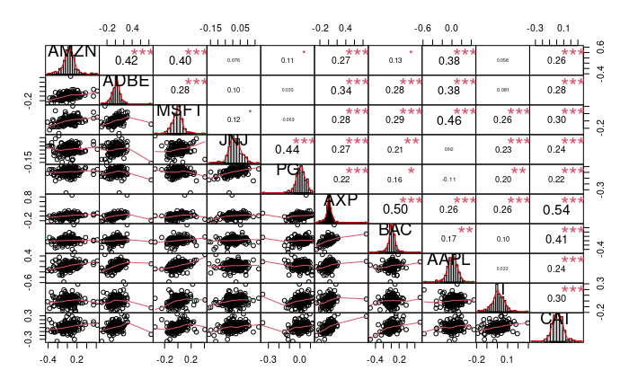

```r
chart.Correlation(R=stock.returns.timeseries.xts,method = "pearson"
                  )
```

Now, we calculate the covariance-matrix. Covariance measures the directional relationship between the returns on two assets. A positive covariance means that asset returns move together while a negative covariance means they move inversely.

```r
covmatrix <- cov(stock.returns.timeseries.xts, use = "everything", method = "pearson")
covmatrix
```

```
             AMZN         ADBE          MSFT          JNJ            PG         AXP          BAC
AMZN 0.0193130707 0.0068383283  0.0047890626 4.925841e-04  0.0008022485 0.003453798 0.0020577028
ADBE 0.0068383283 0.0136627892  0.0027963996 5.409638e-04  0.0002088448 0.003703418 0.0037649285
MSFT 0.0047890626 0.0027963996  0.0072982541 4.789765e-04 -0.0003015010 0.002212118 0.0028588361
JNJ  0.0004925841 0.0005409638  0.0004789765 2.151664e-03  0.0010424325 0.001167048 0.0011248764
PG   0.0008022485 0.0002088448 -0.0003015010 1.042432e-03  0.0026514453 0.001050596 0.0009431238
AXP  0.0034537980 0.0037034182  0.0022121185 1.167048e-03  0.0010505962 0.008660474 0.0054248264
BAC  0.0020577028 0.0037649285  0.0028588361 1.124876e-03  0.0009431238 0.005424826 0.0134142268
AAPL 0.0062283410 0.0053105123  0.0046734660 6.537685e-05 -0.0006562662 0.002889861 0.0023527115
T    0.0005253167 0.0006172893  0.0014419160 7.063349e-04  0.0006685946 0.001553801 0.0007727499
CAT  0.0033346892 0.0029830716  0.0023127167 1.025645e-03  0.0010319008 0.004568791 0.0043426505
              AAPL            T         CAT
AMZN  6.228341e-03 0.0005253167 0.003334689
ADBE  5.310512e-03 0.0006172893 0.002983072
MSFT  4.673466e-03 0.0014419160 0.002312717
JNJ   6.537685e-05 0.0007063349 0.001025645
PG   -6.562662e-04 0.0006685946 0.001031901
AXP   2.889861e-03 0.0015538007 0.004568791
BAC   2.352711e-03 0.0007727499 0.004342651
AAPL  1.394101e-02 0.0001688447 0.002567515
T     1.688447e-04 0.0042326187 0.001790890
CAT   2.567515e-03 0.0017908899 0.008372427
```

2. Plot the average return of the assets against their standard deviation. Are there any dominated assets? Plot the efficient frontier using `chart.EfficientFrontier` and `chart.EF.Weights` (also check the `demo(demo_efficient_frontier)` from the `portfolioAnalytics`-package.

Since we want to ploit the average return of the assets against their standard deviation, we need to calculate mu (=average return) and sigma (=standard deviation).

```r
meanstocks <- stocks.returns.monthly %>%
    dplyr::group_by(symbol) %>%
    dplyr::summarize(mu = mean(Stock.returns, na.rm=TRUE))
stocks.returns.monthly
```

| symbol | date | Stock.returns |
| --- | --- | --- |
| AMZN | Jan 2000 | -0.2776223776 |
| AMZN | Feb 2000 | 0.0667957406 |
| AMZN | Mar 2000 | -0.0272232305 |
| AMZN | Apr 2000 | -0.1763059701 |
| AMZN | May 2000 | -0.1245753114 |
| AMZN | Jun 2000 | -0.2483829237 |
| AMZN | Jul 2000 | -0.1703958692 |
| AMZN | Aug 2000 | 0.3775933610 |
| AMZN | Sep 2000 | -0.0737951807 |
| AMZN | Oct 2000 | -0.0471544715 |

[output cut: 990 more lines]

```r
meanstocks
```

| symbol | mu |
| --- | --- |
| AAPL | 0.026191046 |
| ADBE | 0.018991350 |
| AMZN | 0.023486434 |
| AXP | 0.008712684 |
| BAC | 0.010156820 |
| CAT | 0.015021535 |
| JNJ | 0.008011724 |
| MSFT | 0.008428192 |
| PG | 0.005627146 |
| T | 0.004371813 |

We use the ggrepel package and the the dplyr package.

```r
sdstocks <- stocks.returns.monthly %>%
    dplyr::group_by(symbol) %>%
    dplyr::summarize(sigma = sd(Stock.returns, na.rm=TRUE))
sdstocks
```

| symbol | sigma |
| --- | --- |
| AAPL | 0.11807203 |
| ADBE | 0.11688793 |
| AMZN | 0.13897147 |
| AXP | 0.09306167 |
| BAC | 0.11581980 |
| CAT | 0.09150097 |
| JNJ | 0.04638604 |
| MSFT | 0.08542982 |
| PG | 0.05149219 |
| T | 0.06505858 |

```r
sigmamu <- left_join(sdstocks, meanstocks, by = "symbol")
sigmamu
```

| symbol | sigma | mu |
| --- | --- | --- |
| AAPL | 0.11807203 | 0.026191046 |
| ADBE | 0.11688793 | 0.018991350 |
| AMZN | 0.13897147 | 0.023486434 |
| AXP | 0.09306167 | 0.008712684 |
| BAC | 0.11581980 | 0.010156820 |
| CAT | 0.09150097 | 0.015021535 |
| JNJ | 0.04638604 | 0.008011724 |
| MSFT | 0.08542982 | 0.008428192 |
| PG | 0.05149219 | 0.005627146 |
| T | 0.06505858 | 0.004371813 |

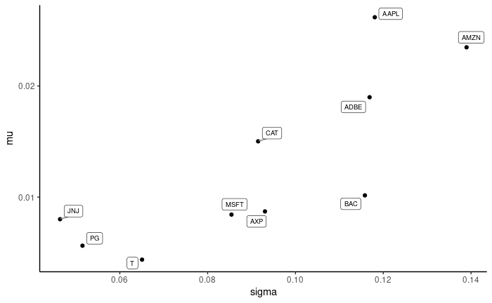

```r
sigmamuggplot <- ggplot(sigmamu, aes(sigma, mu))+
  geom_point()+
  geom_label_repel(aes(label = symbol),
                  box.padding   = 0.2,
                  point.padding = 0.1,
                  label.size = 0.2,
                  segment.color = 'grey50', size = 2.5)+
  theme_classic()
 sigmamuggplot
```

3. Now comes the fun: Work through the vignette of the `portfolioAnalytics`-package (`vignette("portfolio_vignette")`), set a full investment constraint and limit the portfolio weights to be ‘long only’ and calculate minimum-variance/maximum-return and quadratic utility portfolios.

Since we only want to limit the portfolio weights to be “long only”, we specify that.

```r
port <- portfolio.spec(assets = colnames(stock.returns.timeseries.xts),
                       category_labels = stockselection)
port <- add.constraint(portfolio=port, type="long_only")
meanvar.portf <- add.objective(portfolio=port, type="return", name="mean")
meanvar.portf <- add.objective(portfolio=port, type="risk", name="StdDev")
summary(meanvar.portf, digits=2)
```

```
$category_labels
$category_labels$AMZN
[1] 1

$category_labels$ADBE
[1] 2

$category_labels$MSFT
[1] 3

$category_labels$JNJ
[1] 4

$category_labels$PG
[1] 5

$category_labels$AXP
[1] 6

$category_labels$BAC
[1] 7

$category_labels$AAPL
[1] 8

$category_labels$T
[1] 9

$category_labels$CAT
[1] 10


$assets
AMZN ADBE MSFT  JNJ   PG  AXP  BAC AAPL    T  CAT
 0.1  0.1  0.1  0.1  0.1  0.1  0.1  0.1  0.1  0.1

$enabled_constraints
$enabled_constraints[[1]]
An object containing 5 nonlinear constraints.

```

[output cut: 20 more lines]

```
$multiplier
[1] 1

$call
add.objective(portfolio = port, type = "risk", name = "StdDev")

attr(,"class")
[1] "portfolio_risk_objective" "objective"


$disabled_objectives
list()

attr(,"class")
[1] "summary.portfolio"
```

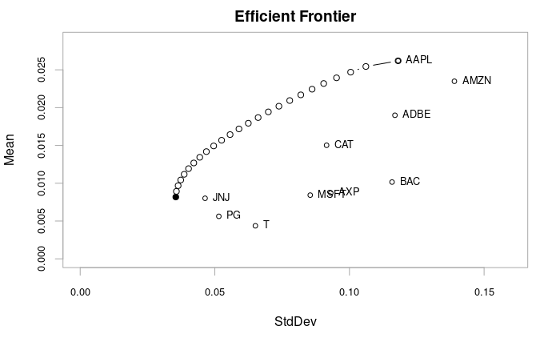

```r
prt_ef <- create.EfficientFrontier(R=stock.returns.timeseries.xts, portfolio=port, type="mean-StdDev", match.col = "StdDev")
chart.EfficientFrontier(prt_ef, match.col="StdDev", type="b", rf=NULL, pch.assets = 1)
```

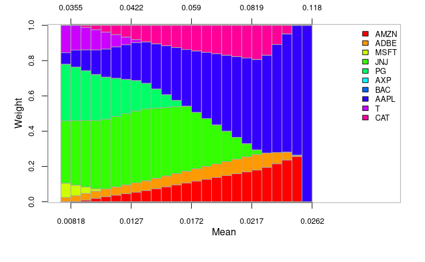

```r
chart.EF.Weights(prt_ef, colorset=rainbow(n = length(stockselection)), match.col="StdDev", cex.lab = 1, main = "StdDev")
```

Now, we set a full investment constraint. This constraint is a special case to set min_sum=1 and max_sum=1 of weight sum constraints.

```r
portfull <- portfolio.spec(assets = colnames(stock.returns.timeseries.xts))
portfull <- add.constraint(portfolio=portfull, type="full_investment")
meanvar.portf.full <- add.objective(portfolio=portfull, type="return", name="mean")
meanvar.portf.full <- add.objective(portfolio=portfull, type="risk", name="StdDev")
prt_ef_full <- create.EfficientFrontier(R=stock.returns.timeseries.xts, portfolio=portfull, type="mean-StdDev", match.col = "StdDev")
```

```
Inf or -Inf values detected in box constraints, maximum return
            objectives must have finite box constraint values.
```

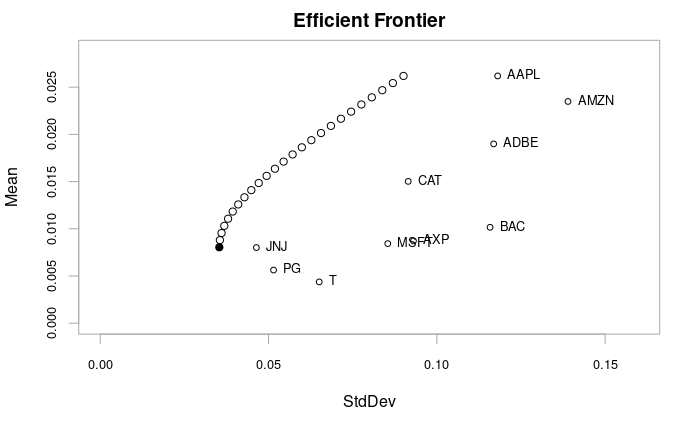

```r
chart.EfficientFrontier(prt_ef_full, match.col="StdDev", type="b", rf=NULL, pch.assets = 1)
```

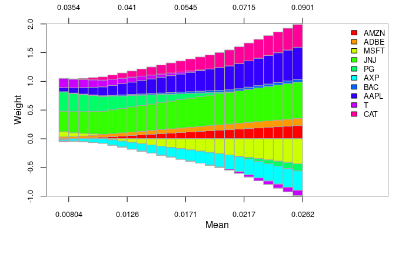

```r
chart.EF.Weights(prt_ef_full, colorset=rainbow(n = length(stockselection)), match.col="StdDev", cex.lab = 1, main = "StdDev")
```

Now, we create the minimum variance portfolio.

```r
port_l <- portfolio.spec(assets = colnames(stock.returns.timeseries.xts))
port_l <- add.constraint(portfolio = port_l,
type = "long_only")
minvar <- add.objective(portfolio = port_l, type = "risk", name = "var")
opt_minvar <- optimize.portfolio(R=stock.returns.timeseries.xts, portfolio = minvar, optimize_method = "ROI", trace = TRUE)
print(opt_minvar)
```

```
PortfolioAnalytics Optimization

Call:
optimize.portfolio(R = stock.returns.timeseries.xts, portfolio = minvar,
    optimize_method = "ROI", trace = TRUE)

Optimal Weights:
  AMZN   ADBE   MSFT    JNJ     PG    AXP    BAC   AAPL      T    CAT
0.0000 0.0243 0.0810 0.3536 0.3211 0.0000 0.0000 0.0656 0.1544 0.0000

Objective Measure:
 StdDev
0.03551
```

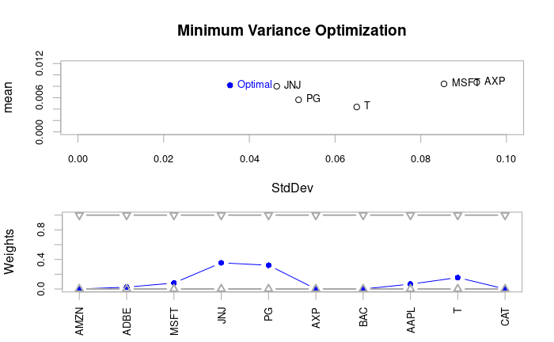

```r
plot(opt_minvar, risk.col="StdDev", return.col="mean",
      main="Minimum Variance Optimization", chart.assets=TRUE,
      xlim=c(0, 0.1), ylim=c(0,0.012))
```

Now, we want to maximize the return with the Return on Investment (ROI). Therefore, we set the “optimize_method” equals ROI.

```r
maxret <-add.objective(portfolio=port_l, type="return", name="mean")
opt_maxret <- optimize.portfolio(R=stock.returns.timeseries.xts, portfolio=maxret,
                                 optimize_method="ROI",
                                 trace=TRUE)
print(opt_maxret)
plot(opt_maxret, risk.col="StdDev", return.col="mean",
       main="Maximum Return Optimization", chart.assets=TRUE,
       xlim=c(0, 0.3), ylim=c(0,0.013))
```

[output not shown]

Now, we want to calculate the quadratic utility portfolio. We set the risk aversion to 0.25.

```r
qu <- add.objective(portfolio=port_l, type="return", name="mean")
qu <- add.objective(portfolio=qu, type="risk", name="var", risk_aversion=0.25)
opt_qu <- optimize.portfolio(R=stock.returns.timeseries.xts, portfolio=qu,
                             optimize_method="ROI",
                             trace=TRUE)
print(opt_qu)
```

```
PortfolioAnalytics Optimization

Call:
optimize.portfolio(R = stock.returns.timeseries.xts, portfolio = qu,
    optimize_method = "ROI", trace = TRUE)

Optimal Weights:
  AMZN   ADBE   MSFT    JNJ     PG    AXP    BAC   AAPL      T    CAT
0.1108 0.0000 0.0000 0.0000 0.0000 0.0000 0.0000 0.8892 0.0000 0.0000

Objective Measure:
   mean
0.02589


StdDev
0.1117
```

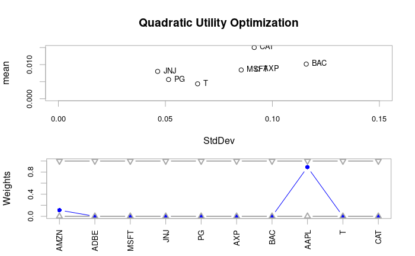

```r
plot(opt_qu, risk.col="StdDev", return.col="mean",
      main="Quadratic Utility Optimization", chart.assets=TRUE,
      xlim=c(0, 0.15), ylim=c(0, 0.015))
```

3. Allow for short selling (delete the long only constraint). What happens to your portfolio? Illustrate using the efficient frontier! Combine efficient frontiers using `chart.EfficientFrontierOverlay` to highlight the differences.

Now, we allow for short selling and want to highlight the differences.

```
Inf or -Inf values detected in box constraints, maximum return
            objectives must have finite box constraint values.
```

[figure not shown]

```r
portf.list <- combine.portfolios(list(port, portfull))
legend.labels <- c("Full Investment", "Long Only")
chart.EfficientFrontierOverlay(R=stock.returns.timeseries.xts,
                               portfolio_list=portf.list, type="mean-StdDev",
                               match.col="StdDev", legend.loc="topleft",
                               legend.labels=legend.labels, cex.legend=0.6,
                               labels.assets=FALSE, pch.assets=1)
```

4. Play around with the constraints and see what happens. Illustrate using `chart.EfficientFrontierOverlay`.

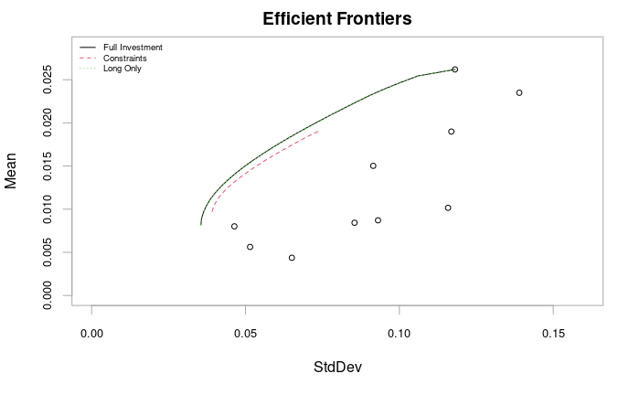

```r
port_c <- add.constraint(portfolio=port, type="diversification", div_target=0.7)
port_c <- add.constraint(portfolio=port_c, type="box", min=0.05, max=0.4)
portf.list.c <- combine.portfolios(list(port, port_c, port_l))
legend.labels <- c("Full Investment", "Constraints", "Long Only")
chart.EfficientFrontierOverlay(R=stock.returns.timeseries.xts,
                               portfolio_list=portf.list.c, type="mean-StdDev",
                               match.col="StdDev", legend.loc="topleft",
                               legend.labels=legend.labels, cex.legend=0.6,
                               labels.assets=FALSE, pch.assets=1)
```

## Exercise 2: Do it yourself

In this exercise you first download the IBoxx Euro Corporate All Maturities (“IBCRPAL”) and the EuroStoxx (“DJES50I”) index from Datastream - monthly data as long as possible. We will check the calculations of `R`. Calculate discrete monthly returns.

In a first step, we downloaded the IBoxx Euro Corporate All Maturities (“IBCRPAL”) and the EuroStoxx (“DJES50I”) index from Datastream. Then, we saved it locally on our computer and imported it to R in excel-format.

```r
Eurostoxx_correct <- read_xlsx("eurostoxx.xlsx")
Eurostoxx_correct
```

| date | price |
| --- | --- |
| 1998-12-31 | 3342.320 |
| 1999-01-29 | 3547.150 |
| 1999-02-26 | 3484.240 |
| 1999-03-31 | 3559.860 |
| 1999-04-30 | 3757.870 |
| 1999-05-31 | 3629.460 |
| 1999-06-30 | 3788.660 |
| 1999-07-30 | 3638.620 |
| 1999-08-31 | 3769.140 |
| 1999-09-30 | 3669.710 |

[output cut: 251 more lines]

```r
View(Eurostoxx_correct)
Iboxx_correct <- read_xlsx("iboxx.xlsx")
Iboxx_correct
```

| date | price |
| --- | --- |
| 1998-12-31 | 100.000 |
| 1999-01-31 | 100.911 |
| 1999-02-28 | 98.742 |
| 1999-03-31 | 99.328 |
| 1999-04-30 | 100.292 |
| 1999-05-31 | 98.300 |
| 1999-06-30 | 96.115 |
| 1999-07-31 | 94.343 |
| 1999-08-31 | 93.524 |
| 1999-09-30 | 92.396 |

[output cut: 251 more lines]

```r
View(Iboxx_correct)
```

Next, we calculate discrete monthly returns for EuroStoxx

```r
monthly_returns_eurostoxx <- Eurostoxx_correct %>%
  mutate(date=as.yearmon(date), price=as.numeric(price))%>%
  tq_transmute(select = price,
               mutate_fun = periodReturn,
               period="monthly",
               type="arithmetic",
               col_rename = "monthly_returns"
               )
monthly_returns_eurostoxx
```

| date | monthly_returns |
| --- | --- |
| Dec 1998 | 0.000000e+00 |
| Jan 1999 | 6.128378e-02 |
| Feb 1999 | -1.773537e-02 |
| Mar 1999 | 2.170344e-02 |
| Apr 1999 | 5.562297e-02 |
| May 1999 | -3.417095e-02 |
| Jun 1999 | 4.386327e-02 |
| Jul 1999 | -3.960239e-02 |
| Aug 1999 | 3.587074e-02 |
| Sep 1999 | -2.638002e-02 |

[output cut: 251 more lines]

Next, we do the same for Iboxx.

```r
monthly_returns_iboxx <- Iboxx_correct %>%
  mutate(date=as.yearmon(date), price=as.numeric(price)) %>%
  tq_transmute(select = price,
               mutate_fun = periodReturn,
               period="monthly",
               type="arithmetic",
               col_rename = "monthly_returns"
               )
monthly_returns_iboxx
```

| date | monthly_returns |
| --- | --- |
| Dec 1998 | 0.000000e+00 |
| Jan 1999 | 9.110000e-03 |
| Feb 1999 | -2.149419e-02 |
| Mar 1999 | 5.934658e-03 |
| Apr 1999 | 9.705219e-03 |
| May 1999 | -1.986200e-02 |
| Jun 1999 | -2.222787e-02 |
| Jul 1999 | -1.843625e-02 |
| Aug 1999 | -8.681089e-03 |
| Sep 1999 | -1.206108e-02 |

[output cut: 251 more lines]

Since we want to use our portfolioanalytics-package, we need the data in xts-format.

```r
eurostoxx_returns_xts <- monthly_returns_eurostoxx %>%
  select(date,monthly_returns) %>%
  tk_xts(silent = TRUE)
eurostoxx_returns_xts
```

```
         monthly_returns
Dec 1998    0.000000e+00
Jan 1999    6.128378e-02
Feb 1999   -1.773537e-02
Mar 1999    2.170344e-02
Apr 1999    5.562297e-02
May 1999   -3.417095e-02
Jun 1999    4.386327e-02
Jul 1999   -3.960239e-02
Aug 1999    3.587074e-02
Sep 1999   -2.638002e-02
Oct 1999    6.899728e-02
Nov 1999    9.979046e-02
Dec 1999    1.367701e-01
Jan 2000   -4.485308e-02
Feb 2000    1.063384e-01
Mar 2000    1.291432e-02
Apr 2000    1.036318e-02
May 2000   -1.943118e-02
Jun 2000   -1.067876e-02
Jul 2000   -4.382794e-03
Aug 2000    1.021317e-02
Sep 2000   -5.022824e-02
Oct 2000    2.894645e-02
Nov 2000   -5.286827e-02
Dec 2000   -3.693259e-03
Jan 2001    1.573846e-03
Feb 2001   -9.644955e-02
Mar 2001   -3.099855e-02
Apr 2001    8.124444e-02
May 2001   -2.182759e-02
Jun 2001   -4.119345e-02
Jul 2001   -3.594000e-02
Aug 2001   -8.491267e-02
Sep 2001   -1.194748e-01
Oct 2001    5.519829e-02
Nov 2001    5.164102e-02
Dec 2001    4.041801e-02
Jan 2002   -3.569768e-02
Feb 2002   -1.240239e-02
```

[output cut: 207 more lines]

```
Jun 2019    5.891521e-02
Jul 2019   -1.970237e-03
Aug 2019   -1.156266e-02
Sep 2019    4.163959e-02
Oct 2019    9.794781e-03
Nov 2019    2.751321e-02
Dec 2019    1.122481e-02
Jan 2020   -2.783490e-02
Feb 2020   -8.553304e-02
Mar 2020   -1.629639e-01
Apr 2020    5.060275e-02
May 2020    4.175887e-02
Jun 2020    6.028170e-02
Jul 2020   -1.847519e-02
Aug 2020    3.093390e-02
```

```r
iboxx_returns_xts <- monthly_returns_iboxx %>%
  select(date,monthly_returns) %>%
  tk_xts(silent = TRUE)
iboxx_returns_xts
```

```
         monthly_returns
Dec 1998    0.000000e+00
Jan 1999    9.110000e-03
Feb 1999   -2.149419e-02
Mar 1999    5.934658e-03
Apr 1999    9.705219e-03
May 1999   -1.986200e-02
Jun 1999   -2.222787e-02
Jul 1999   -1.843625e-02
Aug 1999   -8.681089e-03
Sep 1999   -1.206108e-02
Oct 1999   -1.926490e-03
Nov 1999    3.112191e-03
Dec 1999   -1.081023e-02
Jan 2000   -7.431288e-03
Feb 2000    4.183870e-04
Mar 2000    9.993066e-03
Apr 2000   -6.570703e-03
May 2000   -4.848192e-03
Jun 2000   -2.953949e-03
Jul 2000    2.763714e-03
Aug 2000   -2.734048e-03
Sep 2000    1.746628e-03
Oct 2000   -2.659516e-03
Nov 2000    7.468714e-03
Dec 2000    1.171858e-02
Jan 2001    9.943660e-03
Feb 2001   -4.944376e-04
Mar 2001    3.688608e-03
Apr 2001   -1.111087e-02
May 2001    7.714394e-03
Jun 2001   -1.171955e-03
Jul 2001    1.052768e-02
Aug 2001    6.029230e-03
Sep 2001   -1.247326e-02
Oct 2001    2.305284e-02
Nov 2001   -6.665688e-03
Dec 2001   -1.277723e-02
Jan 2002   -8.550023e-05
Feb 2002   -6.252739e-03
```

[output cut: 207 more lines]

```
Jun 2019    1.663234e-02
Jul 2019    1.088994e-02
Aug 2019    5.261048e-03
Sep 2019   -8.951802e-03
Oct 2019   -4.385568e-03
Nov 2019   -3.556238e-03
Dec 2019   -2.037940e-03
Jan 2020    1.049498e-02
Feb 2020   -5.147746e-03
Mar 2020   -7.144084e-02
Apr 2020    3.636265e-02
May 2020   -7.561357e-04
Jun 2020    1.095124e-02
Jul 2020    1.620734e-02
Aug 2020    9.923274e-04
```

Now, we want to merge them together.

```r
index_final <- left_join(monthly_returns_iboxx, monthly_returns_eurostoxx, by = "date")
index_final
```

| date | monthly_returns.x | monthly_returns.y |
| --- | --- | --- |
| Dec 1998 | 0.000000e+00 | 0.000000e+00 |
| Jan 1999 | 9.110000e-03 | 6.128378e-02 |
| Feb 1999 | -2.149419e-02 | -1.773537e-02 |
| Mar 1999 | 5.934658e-03 | 2.170344e-02 |
| Apr 1999 | 9.705219e-03 | 5.562297e-02 |
| May 1999 | -1.986200e-02 | -3.417095e-02 |
| Jun 1999 | -2.222787e-02 | 4.386327e-02 |
| Jul 1999 | -1.843625e-02 | -3.960239e-02 |
| Aug 1999 | -8.681089e-03 | 3.587074e-02 |
| Sep 1999 | -1.206108e-02 | -2.638002e-02 |

[output cut: 251 more lines]

```r
returns_index_final_xts <- index_final %>%
  select(date, monthly_returns.x, monthly_returns.y) %>%
  tk_xts(silent = TRUE)
returns_index_final_xts
```

```
         monthly_returns.x monthly_returns.y
Dec 1998      0.000000e+00      0.000000e+00
Jan 1999      9.110000e-03      6.128378e-02
Feb 1999     -2.149419e-02     -1.773537e-02
Mar 1999      5.934658e-03      2.170344e-02
Apr 1999      9.705219e-03      5.562297e-02
May 1999     -1.986200e-02     -3.417095e-02
Jun 1999     -2.222787e-02      4.386327e-02
Jul 1999     -1.843625e-02     -3.960239e-02
Aug 1999     -8.681089e-03      3.587074e-02
Sep 1999     -1.206108e-02     -2.638002e-02
Oct 1999     -1.926490e-03      6.899728e-02
Nov 1999      3.112191e-03      9.979046e-02
Dec 1999     -1.081023e-02      1.367701e-01
Jan 2000     -7.431288e-03     -4.485308e-02
Feb 2000      4.183870e-04      1.063384e-01
Mar 2000      9.993066e-03      1.291432e-02
Apr 2000     -6.570703e-03      1.036318e-02
May 2000     -4.848192e-03     -1.943118e-02
Jun 2000     -2.953949e-03     -1.067876e-02
Jul 2000      2.763714e-03     -4.382794e-03
Aug 2000     -2.734048e-03      1.021317e-02
Sep 2000      1.746628e-03     -5.022824e-02
Oct 2000     -2.659516e-03      2.894645e-02
Nov 2000      7.468714e-03     -5.286827e-02
Dec 2000      1.171858e-02     -3.693259e-03
Jan 2001      9.943660e-03      1.573846e-03
Feb 2001     -4.944376e-04     -9.644955e-02
Mar 2001      3.688608e-03     -3.099855e-02
Apr 2001     -1.111087e-02      8.124444e-02
May 2001      7.714394e-03     -2.182759e-02
Jun 2001     -1.171955e-03     -4.119345e-02
Jul 2001      1.052768e-02     -3.594000e-02
Aug 2001      6.029230e-03     -8.491267e-02
Sep 2001     -1.247326e-02     -1.194748e-01
Oct 2001      2.305284e-02      5.519829e-02
Nov 2001     -6.665688e-03      5.164102e-02
Dec 2001     -1.277723e-02      4.041801e-02
Jan 2002     -8.550023e-05     -3.569768e-02
Feb 2002     -6.252739e-03     -1.240239e-02
```

[output cut: 207 more lines]

```
Jun 2019      1.663234e-02      5.891521e-02
Jul 2019      1.088994e-02     -1.970237e-03
Aug 2019      5.261048e-03     -1.156266e-02
Sep 2019     -8.951802e-03      4.163959e-02
Oct 2019     -4.385568e-03      9.794781e-03
Nov 2019     -3.556238e-03      2.751321e-02
Dec 2019     -2.037940e-03      1.122481e-02
Jan 2020      1.049498e-02     -2.783490e-02
Feb 2020     -5.147746e-03     -8.553304e-02
Mar 2020     -7.144084e-02     -1.629639e-01
Apr 2020      3.636265e-02      5.060275e-02
May 2020     -7.561357e-04      4.175887e-02
Jun 2020      1.095124e-02      6.028170e-02
Jul 2020      1.620734e-02     -1.847519e-02
Aug 2020      9.923274e-04      3.093390e-02
```

1. Stats/Normality (see A1)

First, we calculate the monthly returns for EuroStoxx.

```r
monthly_returns_eurostoxx %>%
  tq_performance(Ra = monthly_returns, Rb = NULL, performance_fun = table.Stats)
```

| ArithmeticMean | GeometricMean | Kurtosis | LCLMean(0.95) | Maximum | Median | Minimum | NAs | Observations | Quartile1 | Quartile3 | SEMean | Skewness | Stdev | UCLMean(0.95) | Variance |
| --- | --- | --- | --- | --- | --- | --- | --- | --- | --- | --- | --- | --- | --- | --- | --- |
| 0.0013 | -1e-04 | 0.9615 | -0.0051 | 0.1469 | 0.0071 | -0.1864 | 0 | 261 | -0.0317 | 0.0353 | 0.0033 | -0.4347 | 0.0526 | 0.0077 | 0.0028 |

```r
monthly_returns_eurostoxx
```

| date | monthly_returns |
| --- | --- |
| Dec 1998 | 0.000000e+00 |
| Jan 1999 | 6.128378e-02 |
| Feb 1999 | -1.773537e-02 |
| Mar 1999 | 2.170344e-02 |
| Apr 1999 | 5.562297e-02 |
| May 1999 | -3.417095e-02 |
| Jun 1999 | 4.386327e-02 |
| Jul 1999 | -3.960239e-02 |
| Aug 1999 | 3.587074e-02 |
| Sep 1999 | -2.638002e-02 |

[output cut: 251 more lines]

Next, we calculate the monthly returns for Iboxx.

```r
monthly_returns_iboxx %>%
  tq_performance(Ra = monthly_returns, Rb = NULL, performance_fun = table.Stats)
```

| ArithmeticMean | GeometricMean | Kurtosis | LCLMean(0.95) | Maximum | Median | Minimum | NAs | Observations | Quartile1 | Quartile3 | SEMean | Skewness | Stdev | UCLMean(0.95) | Variance |
| --- | --- | --- | --- | --- | --- | --- | --- | --- | --- | --- | --- | --- | --- | --- | --- |
| 0 | -1e-04 | 7.2481 | -0.0014 | 0.0364 | 6e-04 | -0.0714 | 0 | 261 | -0.0065 | 0.0071 | 7e-04 | -1.3054 | 0.0116 | 0.0014 | 1e-04 |

```r
monthly_returns_iboxx
```

| date | monthly_returns |
| --- | --- |
| Dec 1998 | 0.000000e+00 |
| Jan 1999 | 9.110000e-03 |
| Feb 1999 | -2.149419e-02 |
| Mar 1999 | 5.934658e-03 |
| Apr 1999 | 9.705219e-03 |
| May 1999 | -1.986200e-02 |
| Jun 1999 | -2.222787e-02 |
| Jul 1999 | -1.843625e-02 |
| Aug 1999 | -8.681089e-03 |
| Sep 1999 | -1.206108e-02 |

[output cut: 251 more lines]

Then, we want to plot a histogramm in order to check the normality.

First, we do it for the eurostoxx.

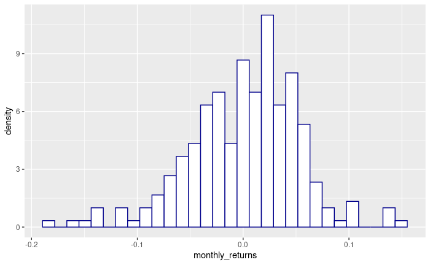

```r
monthly_returns_eurostoxx %>%
  ggplot(aes(x=monthly_returns)) +
  geom_histogram(aes(y=..density..), colour="darkblue", fill="white")
```

As we can see above, the monthly returns are skewed to the left. Furthermore, it is almost normally distributed.

Then, we do it for the iboxx.

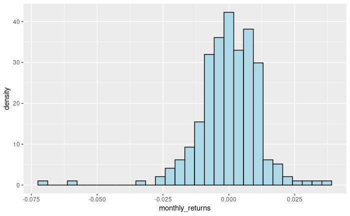

```r
monthly_returns_iboxx %>%
  ggplot(aes(x=monthly_returns)) +
  geom_histogram(aes(y=..density..), colour="black", fill="lightblue")
```

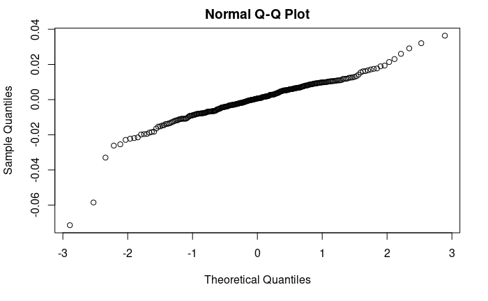

```r
qqnorm(monthly_returns_iboxx$monthly_returns)
```

Now, we do a qq-plot for the monthly returns of EuroStoxx. As we can see below, it is also almost normally distributed because of the almost-linear character of the line.

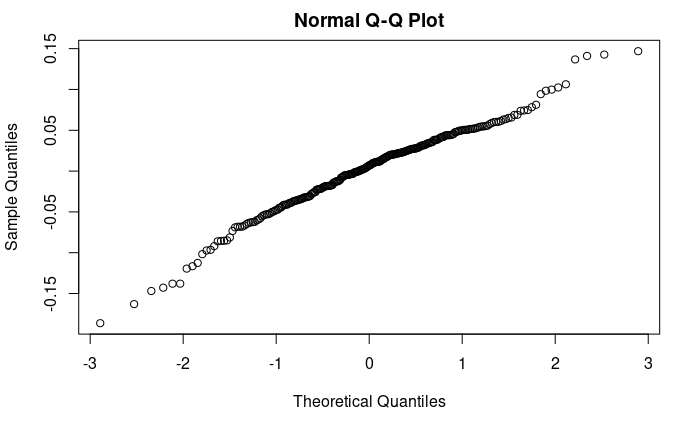

```r
qqnorm(monthly_returns_eurostoxx$monthly_returns)
```

2. Get the necessary input parameters (mu, sigma, please using variables, I don’t want to see manual numbers in your code) and calculate the Minimum-Variance-Portfolio (manually in R). Then do it using the `portfolioAnalytics`-package.

First, we calculate “mu” for each index. We create a column for each index and name them.

```r
returns_index_final_xts
```

```
         monthly_returns.x monthly_returns.y
Dec 1998      0.000000e+00      0.000000e+00
Jan 1999      9.110000e-03      6.128378e-02
Feb 1999     -2.149419e-02     -1.773537e-02
Mar 1999      5.934658e-03      2.170344e-02
Apr 1999      9.705219e-03      5.562297e-02
May 1999     -1.986200e-02     -3.417095e-02
Jun 1999     -2.222787e-02      4.386327e-02
Jul 1999     -1.843625e-02     -3.960239e-02
Aug 1999     -8.681089e-03      3.587074e-02
Sep 1999     -1.206108e-02     -2.638002e-02
Oct 1999     -1.926490e-03      6.899728e-02
Nov 1999      3.112191e-03      9.979046e-02
Dec 1999     -1.081023e-02      1.367701e-01
Jan 2000     -7.431288e-03     -4.485308e-02
Feb 2000      4.183870e-04      1.063384e-01
Mar 2000      9.993066e-03      1.291432e-02
Apr 2000     -6.570703e-03      1.036318e-02
May 2000     -4.848192e-03     -1.943118e-02
Jun 2000     -2.953949e-03     -1.067876e-02
Jul 2000      2.763714e-03     -4.382794e-03
Aug 2000     -2.734048e-03      1.021317e-02
Sep 2000      1.746628e-03     -5.022824e-02
Oct 2000     -2.659516e-03      2.894645e-02
Nov 2000      7.468714e-03     -5.286827e-02
Dec 2000      1.171858e-02     -3.693259e-03
Jan 2001      9.943660e-03      1.573846e-03
Feb 2001     -4.944376e-04     -9.644955e-02
Mar 2001      3.688608e-03     -3.099855e-02
Apr 2001     -1.111087e-02      8.124444e-02
May 2001      7.714394e-03     -2.182759e-02
Jun 2001     -1.171955e-03     -4.119345e-02
Jul 2001      1.052768e-02     -3.594000e-02
Aug 2001      6.029230e-03     -8.491267e-02
Sep 2001     -1.247326e-02     -1.194748e-01
Oct 2001      2.305284e-02      5.519829e-02
Nov 2001     -6.665688e-03      5.164102e-02
Dec 2001     -1.277723e-02      4.041801e-02
Jan 2002     -8.550023e-05     -3.569768e-02
Feb 2002     -6.252739e-03     -1.240239e-02
```

[output cut: 207 more lines]

```
Jun 2019      1.663234e-02      5.891521e-02
Jul 2019      1.088994e-02     -1.970237e-03
Aug 2019      5.261048e-03     -1.156266e-02
Sep 2019     -8.951802e-03      4.163959e-02
Oct 2019     -4.385568e-03      9.794781e-03
Nov 2019     -3.556238e-03      2.751321e-02
Dec 2019     -2.037940e-03      1.122481e-02
Jan 2020      1.049498e-02     -2.783490e-02
Feb 2020     -5.147746e-03     -8.553304e-02
Mar 2020     -7.144084e-02     -1.629639e-01
Apr 2020      3.636265e-02      5.060275e-02
May 2020     -7.561357e-04      4.175887e-02
Jun 2020      1.095124e-02      6.028170e-02
Jul 2020      1.620734e-02     -1.847519e-02
Aug 2020      9.923274e-04      3.093390e-02
```

```r
colnames(returns_index_final_xts) <- c("ibox", "eurostoxx")
returns_index_final_xts
```

```
                  ibox     eurostoxx
Dec 1998  0.000000e+00  0.000000e+00
Jan 1999  9.110000e-03  6.128378e-02
Feb 1999 -2.149419e-02 -1.773537e-02
Mar 1999  5.934658e-03  2.170344e-02
Apr 1999  9.705219e-03  5.562297e-02
May 1999 -1.986200e-02 -3.417095e-02
Jun 1999 -2.222787e-02  4.386327e-02
Jul 1999 -1.843625e-02 -3.960239e-02
Aug 1999 -8.681089e-03  3.587074e-02
Sep 1999 -1.206108e-02 -2.638002e-02
Oct 1999 -1.926490e-03  6.899728e-02
Nov 1999  3.112191e-03  9.979046e-02
Dec 1999 -1.081023e-02  1.367701e-01
Jan 2000 -7.431288e-03 -4.485308e-02
Feb 2000  4.183870e-04  1.063384e-01
Mar 2000  9.993066e-03  1.291432e-02
Apr 2000 -6.570703e-03  1.036318e-02
May 2000 -4.848192e-03 -1.943118e-02
Jun 2000 -2.953949e-03 -1.067876e-02
Jul 2000  2.763714e-03 -4.382794e-03
Aug 2000 -2.734048e-03  1.021317e-02
Sep 2000  1.746628e-03 -5.022824e-02
Oct 2000 -2.659516e-03  2.894645e-02
Nov 2000  7.468714e-03 -5.286827e-02
Dec 2000  1.171858e-02 -3.693259e-03
Jan 2001  9.943660e-03  1.573846e-03
Feb 2001 -4.944376e-04 -9.644955e-02
Mar 2001  3.688608e-03 -3.099855e-02
Apr 2001 -1.111087e-02  8.124444e-02
May 2001  7.714394e-03 -2.182759e-02
Jun 2001 -1.171955e-03 -4.119345e-02
Jul 2001  1.052768e-02 -3.594000e-02
Aug 2001  6.029230e-03 -8.491267e-02
Sep 2001 -1.247326e-02 -1.194748e-01
Oct 2001  2.305284e-02  5.519829e-02
Nov 2001 -6.665688e-03  5.164102e-02
Dec 2001 -1.277723e-02  4.041801e-02
Jan 2002 -8.550023e-05 -3.569768e-02
Feb 2002 -6.252739e-03 -1.240239e-02
```

[output cut: 207 more lines]

```
Jun 2019  1.663234e-02  5.891521e-02
Jul 2019  1.088994e-02 -1.970237e-03
Aug 2019  5.261048e-03 -1.156266e-02
Sep 2019 -8.951802e-03  4.163959e-02
Oct 2019 -4.385568e-03  9.794781e-03
Nov 2019 -3.556238e-03  2.751321e-02
Dec 2019 -2.037940e-03  1.122481e-02
Jan 2020  1.049498e-02 -2.783490e-02
Feb 2020 -5.147746e-03 -8.553304e-02
Mar 2020 -7.144084e-02 -1.629639e-01
Apr 2020  3.636265e-02  5.060275e-02
May 2020 -7.561357e-04  4.175887e-02
Jun 2020  1.095124e-02  6.028170e-02
Jul 2020  1.620734e-02 -1.847519e-02
Aug 2020  9.923274e-04  3.093390e-02
```

Now, we calculate the “mu” of the returns.

```r
mu_returns_index_final_xts <- lapply(returns_index_final_xts, FUN=mean)
mu_returns_index_final_xts
```

```
$ibox
[1] -1.549592e-05

$eurostoxx
[1] 0.001325238
```

Next, we calculate “sigma” for each index.

```r
sigma_returns_index_final_xts <- lapply(returns_index_final_xts,FUN=sd)
sigma_returns_index_final_xts
```

```
$ibox
[1] 0.01161256

$eurostoxx
[1] 0.05263677
```

We want to calculate the minimum-variance-portfolio.We do not allow for short selling, therefore we set type=long_only. As we can see from the weights, we would invest all in Iboxx (weights = 1) and nothing in EuroStoxx (weights = 0).

```r
labels <- c("iboxx", "eurostoxx")
port_l <- portfolio.spec(assets = colnames(returns_index_final_xts), category_labels = labels)
port_l <- add.constraint(portfolio=port_l,type="long_only")
minvar <- add.objective(portfolio=port_l, type="risk", name="var")
opt_minvar <- optimize.portfolio(R=returns_index_final_xts, portfolio=minvar, optimize_method="ROI", trace=TRUE)
print(opt_minvar)
```

```
PortfolioAnalytics Optimization

Call:
optimize.portfolio(R = returns_index_final_xts, portfolio = minvar,
    optimize_method = "ROI", trace = TRUE)

Optimal Weights:
     ibox eurostoxx
        1         0

Objective Measure:
 StdDev
0.01161
```

```r
# allow for shortselling (NOT WORKING)
portf_minvar <- portfolio.spec(assets=returns_index_final_xts)
# Add full investment constraint to the portfolio object
portf_minvar <- add.constraint(portfolio=portf_minvar, type="full_investment")
minvarsh <- add.objective(portfolio=portf_minvar, type="risk", name="var")
opt_minvar <- optimize.portfolio(R=returns_index_final_xts, portfolio=minvar, optimize_method="ROI", trace=TRUE)
print(opt_minvar)
```

```
PortfolioAnalytics Optimization

Call:
optimize.portfolio(R = returns_index_final_xts, portfolio = minvar,
    optimize_method = "ROI", trace = TRUE)

Optimal Weights:
     ibox eurostoxx
        1         0

Objective Measure:
 StdDev
0.01161
```

```r
mu <- colMeans(returns_index_final_xts)
Sigma <- cov(returns_index_final_xts)
ones <- rep(1,ncol(returns_index_final_xts))
wMVP <- t(solve(Sigma) %*% ones)/drop(ones %*% solve(Sigma) %*% ones)
muMVP <- drop(wMVP%*%mu)
sigmaMVP <- drop(wMVP %*% Sigma %*% t(wMVP))^0.5
srMVP <- muMVP/sigmaMVP
round(cbind(wMVP,"mean"=muMVP,"sd"=sigmaMVP,"sr"=srMVP),4)
```

```
       ibox eurostoxx mean     sd      sr
[1,] 1.0174   -0.0174    0 0.0116 -0.0034
```

```r
mu <- colMeans(returns_index_final_xts)
Sigma <- cov(returns_index_final_xts)
ones <- rep(1,ncol(returns_index_final_xts))
wMVP <- t(solve(Sigma) %*% ones)/drop(ones %*% solve(Sigma) %*% ones)
muMVP <- drop(wMVP%*%mu)
sigmaMVP <- drop(wMVP %*% Sigma %*% t(wMVP))^0.5
srMVP <- muMVP/sigmaMVP
round(cbind(wMVP,"mean"=muMVP,"sd"=sigmaMVP,"sr"=srMVP),4)
```

```
       ibox eurostoxx mean     sd      sr
[1,] 1.0174   -0.0174    0 0.0116 -0.0034
```

Now, we want to do it manually.